# Tugas 4 MPDW

Alfiah Ayu Hapsari (G1401211063)

2023-09-21

### 1. Proses MA(2)

Membangkitkan model MA (2) dengan $\theta1 = 0.4$ dan $\theta1 = 0.6$ sebanyak 300 data (manual dan dengan arima.sim)

## White Noise

Pembangkitan data berpola AR, MA, ARMA, dan banyak proses deret waktu lainnya diawali pembangkitan *white noise*. *White noise* merupakan sederet nilai dari peubah bebas stokastik identik. Oleh karena itu, *white noise* memiliki dua karakteristik penting:

1. *White noise* tidak memiliki autokorelasi (**karena saling bebas**)
2. Nilai harapan dan ragam *white noise* sama (**karena berasal dari peubah acak bebas stokastik identik**)

*White noise* dibangkitkan dari suatu peubah acak, umumnya peubah acak normal.

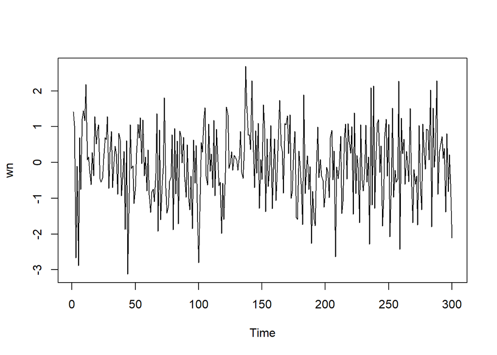

```r
wn <- rnorm(300)
ts.plot(wn)
```

Dapat terlihat bahwa *white noise* tidak memiliki autokorelasi dari ACF. Perhatikan bahwa lag ke-0 adalah korelasi observasi ke-t dengan dirinya sendiri. Nilai korelasi tersebut pasti 1. Sebagai alternatif, lag pertama di plot ACF dapat ditetapkan sebagai 1 (alih-alih 0) dengan menambahkan argumen `xlim(1, lag akhir)`. Plot tersebut dapat disandingkan bersamaan dengan membuat matriks $1 \times 2$ dengan `par(mfrow = c(1,2))`.

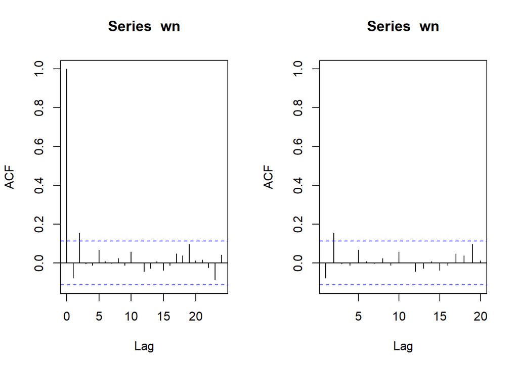

```r
par(mfrow = c(1, 2))
acf(wn)
acf(wn, xlim = c(1, 20))
```

## Proses MA

Proses MA dapat dituliskan sebagai berikut:

$$y_{t} = c + e_t + \theta_{1}e_{t-1} + \theta_{2}e_{t-2} + \dots +
\theta_{q}e_{t-q} = c+{e_t+\sum_{i=1}^p \theta_ie_{t-i}}$$
Terlihat bahwa $e_t$, atau *white noise*, berperan penting dalam pembangkitan proses MA.

```r
set.seed(063)
ma <- wn[c(1,2)]
```

$$y_t = e_t+0.4e_{t-1}+0.6e_{t-2}$$

```r
for(i in 3:300){
   ma[i] <- wn[i] + 0.4 * wn[i - 1] + 0.6 * wn[i - 2]
}
ma
```

```
##   [1]  1.418438909  1.032253740 -1.401313345 -0.545122186 -4.516138724
##   [6] -0.517184848 -2.196839295  1.341672254  1.489708164  2.480745955
##  [11]  3.516217238  1.641119265  1.493265520 -0.112567444 -0.606538260
##  [16] -0.090040776 -0.628339148  1.305961282  0.803804739  1.858909091
##  [21]  1.713819783  0.493992110 -0.098237255 -0.928229190 -0.393743558
##  [26]  0.471336113  0.981628875  1.957765309  0.177237413  0.779692917
##  [31]  0.551670992 -0.173546183  0.114740245 -0.008829365  0.361681480
##  [36] -0.508715995  0.619187000  0.417936424 -0.189634638 -0.478394035
##  [41] -0.442406608 -2.035332929  0.045161146 -3.999965282 -1.742005629
##  [46] -1.157619178 -0.252982216  0.479544269 -1.274520547 -1.188770713
##  [51] -0.681983376  0.766196375  1.274053548  2.164524447  0.880140868
##  [56]  1.925034041  0.080448592  0.717967871 -0.960424116  0.129016572
##  [61] -1.249115205 -1.541806322 -1.927828118 -1.901592185 -1.888501201
##  [66] -1.191749314  0.584204834 -1.555853130  0.969357600 -2.385772227
##  [71] -0.739629854 -1.387145946  1.359025807 -0.090131805 -0.615051976
```

[output cut: 45 more lines]

```r
ma1 <- arima.sim(list(order=c(0,0,2), ma=c(0.4, 0.6)), n=300)
ma1
```

```
## Time Series:
## Start = 1
## End = 300
## Frequency = 1
##   [1]  0.537598792 -2.826891326  0.082468500 -1.992967744  0.301805524
##   [6] -0.349753528 -1.358995253 -0.158110728 -0.439948863  0.263424256
##  [11]  0.512890808  0.228870310  0.034004466  0.227984402 -0.444815934
##  [16]  0.888843683  1.087782638  2.120889179  2.044714891  0.327374502
##  [21] -0.593643051 -0.215761205 -1.017575656  1.902997696  1.060325417
##  [26]  0.065460676  0.408560090 -0.482704095 -1.033430653 -0.054975242
##  [31] -0.089314190  0.353015680  1.280482725  0.984335714 -0.673182491
##  [36]  1.353381421  0.688452565  2.191024999  0.613474413  0.388010395
##  [41] -0.240378758 -0.998654353 -3.446227292 -0.294169547 -0.745248240
##  [46]  2.304608637  1.014429592  0.634722890  0.624012771  0.211330304
##  [51]  0.460726989 -1.141352257 -0.741810014 -3.349781571 -1.645704280
```

[output cut: 49 more lines]

### Plot Time Series

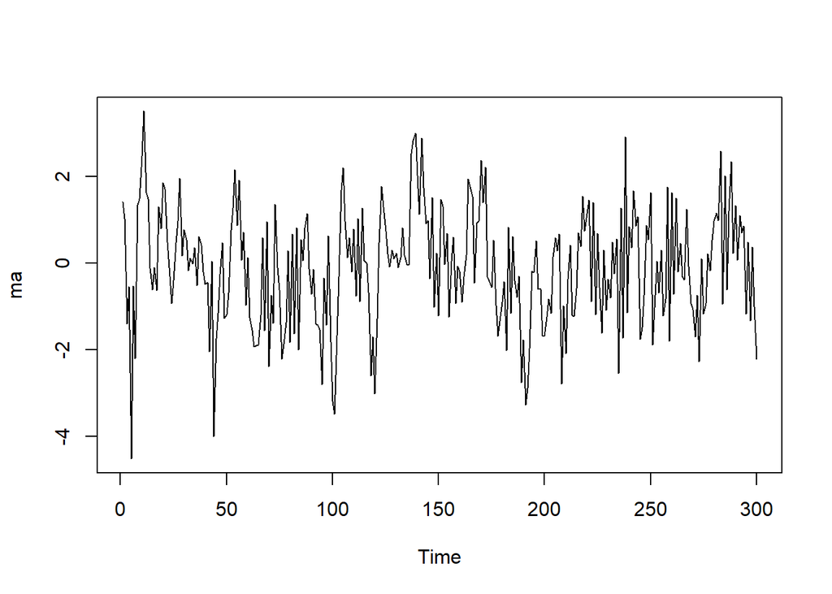

```r
ts.plot(ma)
```

### Plot ACF

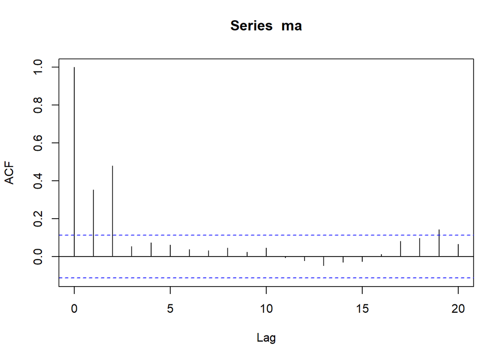

```r
acf(ma,lag.max = 20)
```

Berdasarkan plot AFC tersebut, terlihat bahwa plot ACF *cuts off* di lag pertama dan kedua

### Plot PACF

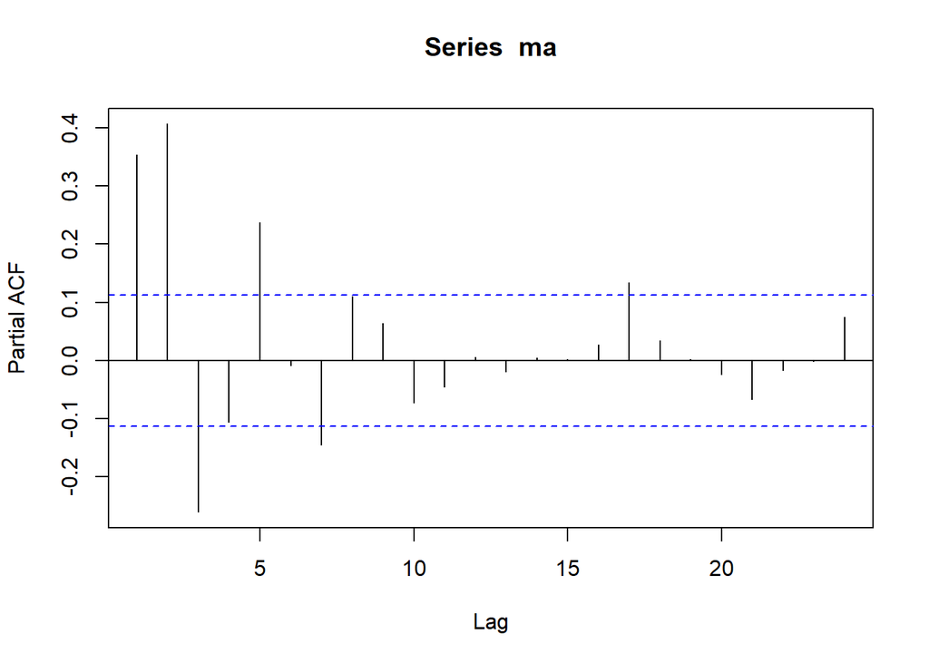

```r
pacf(ma)
```

Berdasarkan plot PACF tersebut, terlihat bahwa plot PACF cenderung *tails off* dan membentuk gelombang sinus

### Plot EACF

```r
TSA::eacf(ma)
```

```
## AR/MA
##   0 1 2 3 4 5 6 7 8 9 10 11 12 13
## 0 x x o o o o o o o o o  o  o  o
## 1 x x x o o o o o o o o  o  o  o
## 2 x x x x o o o o o o o  o  o  o
## 3 x x x x o o o o o o o  o  o  o
## 4 x x x o x o o o o o o  o  o  o
## 5 o x x x o o o o o o o  o  o  o
## 6 o x x x o o o o o o o  o  o  o
## 7 x x x x o o o x x o o  o  o  o
```

Berdasarkan pola segitiga nol pada plot EACF, terlihat bahwa segitiga nol berada pada ordo AR(0) dan ordo MA(2).

Sehingga dapat disimpulkan bahwa data tersebut stasioner.

### Scatterplot Antar Lag

#### Korelasi antara $Y_t$ dengan $Y_{t-1}$

```r
#Yt
yt_ma <- ma[-1]
yt_ma
```

```
##   [1]  1.032253740 -1.401313345 -0.545122186 -4.516138724 -0.517184848
##   [6] -2.196839295  1.341672254  1.489708164  2.480745955  3.516217238
##  [11]  1.641119265  1.493265520 -0.112567444 -0.606538260 -0.090040776
##  [16] -0.628339148  1.305961282  0.803804739  1.858909091  1.713819783
##  [21]  0.493992110 -0.098237255 -0.928229190 -0.393743558  0.471336113
##  [26]  0.981628875  1.957765309  0.177237413  0.779692917  0.551670992
##  [31] -0.173546183  0.114740245 -0.008829365  0.361681480 -0.508715995
##  [36]  0.619187000  0.417936424 -0.189634638 -0.478394035 -0.442406608
##  [41] -2.035332929  0.045161146 -3.999965282 -1.742005629 -1.157619178
##  [46] -0.252982216  0.479544269 -1.274520547 -1.188770713 -0.681983376
##  [51]  0.766196375  1.274053548  2.164524447  0.880140868  1.925034041
##  [56]  0.080448592  0.717967871 -0.960424116  0.129016572 -1.249115205
##  [61] -1.541806322 -1.927828118 -1.901592185 -1.888501201 -1.191749314
##  [66]  0.584204834 -1.555853130  0.969357600 -2.385772227 -0.739629854
##  [71] -1.387145946  1.359025807 -0.090131805 -0.615051976 -2.217959988
```

[output cut: 45 more lines]

```r
#Yt-1
yt_1_ma <- ma[-300]
yt_1_ma
```

```
##   [1]  1.418438909  1.032253740 -1.401313345 -0.545122186 -4.516138724
##   [6] -0.517184848 -2.196839295  1.341672254  1.489708164  2.480745955
##  [11]  3.516217238  1.641119265  1.493265520 -0.112567444 -0.606538260
##  [16] -0.090040776 -0.628339148  1.305961282  0.803804739  1.858909091
##  [21]  1.713819783  0.493992110 -0.098237255 -0.928229190 -0.393743558
##  [26]  0.471336113  0.981628875  1.957765309  0.177237413  0.779692917
##  [31]  0.551670992 -0.173546183  0.114740245 -0.008829365  0.361681480
##  [36] -0.508715995  0.619187000  0.417936424 -0.189634638 -0.478394035
##  [41] -0.442406608 -2.035332929  0.045161146 -3.999965282 -1.742005629
##  [46] -1.157619178 -0.252982216  0.479544269 -1.274520547 -1.188770713
##  [51] -0.681983376  0.766196375  1.274053548  2.164524447  0.880140868
##  [56]  1.925034041  0.080448592  0.717967871 -0.960424116  0.129016572
##  [61] -1.249115205 -1.541806322 -1.927828118 -1.901592185 -1.888501201
##  [66] -1.191749314  0.584204834 -1.555853130  0.969357600 -2.385772227
##  [71] -0.739629854 -1.387145946  1.359025807 -0.090131805 -0.615051976
```

[output cut: 45 more lines]

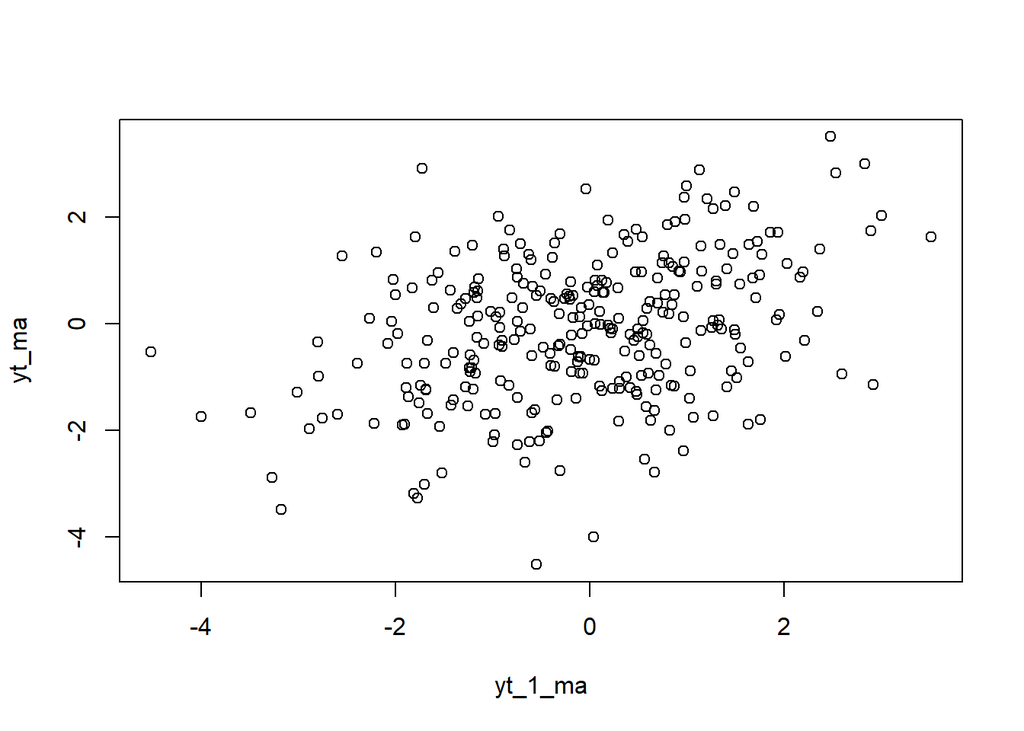

```r
plot(y=yt_ma,x=yt_1_ma)
```

Berdasarkan scatterplot tersebut, terlihat bahwa terdapat hubungan positif antara $Y_t$ dengan $Y_{t-1}$. Hal ini sesuai dengan teori yang ada

```r
cor(yt_ma,yt_1_ma)
```

```
## [1] 0.3553264
```

#### Korelasi antara $Y_t$ dengan $Y_{t-2}$

```r
#Yt
yt_ma2 <- ma[-c(1,2)]
yt_ma2
```

```
##   [1] -1.401313345 -0.545122186 -4.516138724 -0.517184848 -2.196839295
##   [6]  1.341672254  1.489708164  2.480745955  3.516217238  1.641119265
##  [11]  1.493265520 -0.112567444 -0.606538260 -0.090040776 -0.628339148
##  [16]  1.305961282  0.803804739  1.858909091  1.713819783  0.493992110
##  [21] -0.098237255 -0.928229190 -0.393743558  0.471336113  0.981628875
##  [26]  1.957765309  0.177237413  0.779692917  0.551670992 -0.173546183
##  [31]  0.114740245 -0.008829365  0.361681480 -0.508715995  0.619187000
##  [36]  0.417936424 -0.189634638 -0.478394035 -0.442406608 -2.035332929
##  [41]  0.045161146 -3.999965282 -1.742005629 -1.157619178 -0.252982216
##  [46]  0.479544269 -1.274520547 -1.188770713 -0.681983376  0.766196375
##  [51]  1.274053548  2.164524447  0.880140868  1.925034041  0.080448592
##  [56]  0.717967871 -0.960424116  0.129016572 -1.249115205 -1.541806322
##  [61] -1.927828118 -1.901592185 -1.888501201 -1.191749314  0.584204834
##  [66] -1.555853130  0.969357600 -2.385772227 -0.739629854 -1.387145946
##  [71]  1.359025807 -0.090131805 -0.615051976 -2.217959988 -1.862830837
```

[output cut: 45 more lines]

```r
#Yt-2
yt_2_ma <- ma[-c(299,300)]
yt_2_ma
```

```
##   [1]  1.418438909  1.032253740 -1.401313345 -0.545122186 -4.516138724
##   [6] -0.517184848 -2.196839295  1.341672254  1.489708164  2.480745955
##  [11]  3.516217238  1.641119265  1.493265520 -0.112567444 -0.606538260
##  [16] -0.090040776 -0.628339148  1.305961282  0.803804739  1.858909091
##  [21]  1.713819783  0.493992110 -0.098237255 -0.928229190 -0.393743558
##  [26]  0.471336113  0.981628875  1.957765309  0.177237413  0.779692917
##  [31]  0.551670992 -0.173546183  0.114740245 -0.008829365  0.361681480
##  [36] -0.508715995  0.619187000  0.417936424 -0.189634638 -0.478394035
##  [41] -0.442406608 -2.035332929  0.045161146 -3.999965282 -1.742005629
##  [46] -1.157619178 -0.252982216  0.479544269 -1.274520547 -1.188770713
##  [51] -0.681983376  0.766196375  1.274053548  2.164524447  0.880140868
##  [56]  1.925034041  0.080448592  0.717967871 -0.960424116  0.129016572
##  [61] -1.249115205 -1.541806322 -1.927828118 -1.901592185 -1.888501201
##  [66] -1.191749314  0.584204834 -1.555853130  0.969357600 -2.385772227
##  [71] -0.739629854 -1.387145946  1.359025807 -0.090131805 -0.615051976
```

[output cut: 45 more lines]

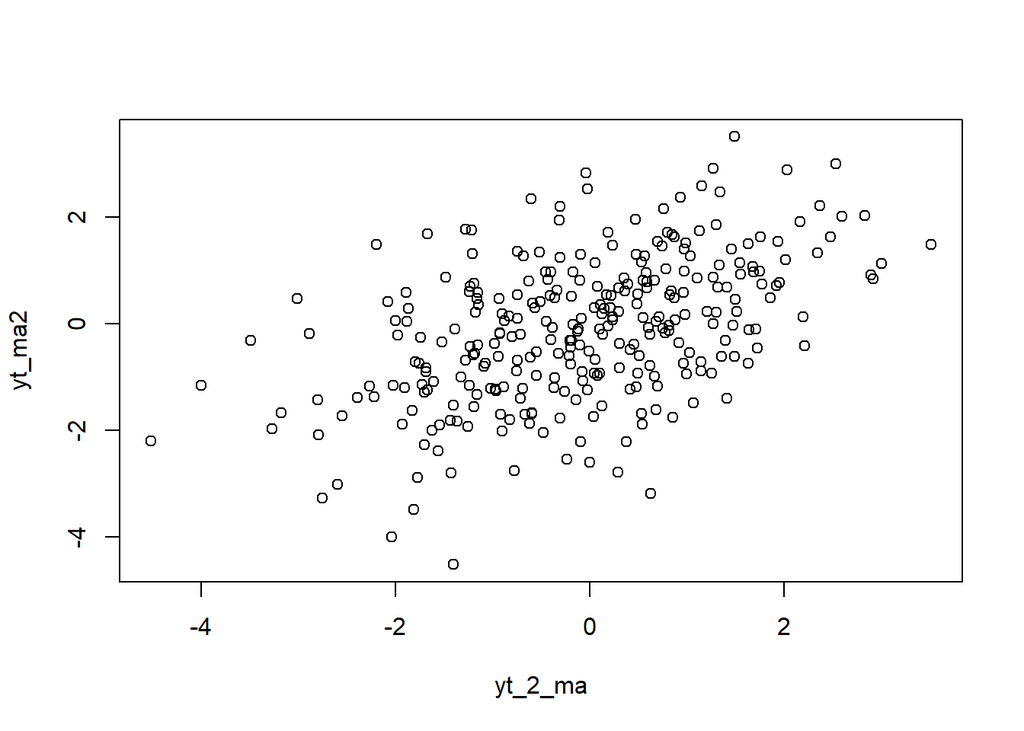

```r
plot(y=yt_ma2,x=yt_2_ma)
```

Berdasarkan scatterplot tersebut, terlihat bahwa terdapat hubungan positif antara $Y_t$ dengan $Y_{t-2}$. Hal ini sesuai dengan teori yang ada

```r
cor(yt_ma2,yt_2_ma)
```

```
## [1] 0.4844638
```

#### Korelasi antara $Y_t$ dengan $Y_{t-3}$

```r
#Yt
yt_ma3 <- ma[-c(1,2,3)]
yt_ma3
```

```
##   [1] -0.545122186 -4.516138724 -0.517184848 -2.196839295  1.341672254
##   [6]  1.489708164  2.480745955  3.516217238  1.641119265  1.493265520
##  [11] -0.112567444 -0.606538260 -0.090040776 -0.628339148  1.305961282
##  [16]  0.803804739  1.858909091  1.713819783  0.493992110 -0.098237255
##  [21] -0.928229190 -0.393743558  0.471336113  0.981628875  1.957765309
##  [26]  0.177237413  0.779692917  0.551670992 -0.173546183  0.114740245
##  [31] -0.008829365  0.361681480 -0.508715995  0.619187000  0.417936424
##  [36] -0.189634638 -0.478394035 -0.442406608 -2.035332929  0.045161146
##  [41] -3.999965282 -1.742005629 -1.157619178 -0.252982216  0.479544269
##  [46] -1.274520547 -1.188770713 -0.681983376  0.766196375  1.274053548
##  [51]  2.164524447  0.880140868  1.925034041  0.080448592  0.717967871
##  [56] -0.960424116  0.129016572 -1.249115205 -1.541806322 -1.927828118
##  [61] -1.901592185 -1.888501201 -1.191749314  0.584204834 -1.555853130
##  [66]  0.969357600 -2.385772227 -0.739629854 -1.387145946  1.359025807
##  [71] -0.090131805 -0.615051976 -2.217959988 -1.862830837 -1.365685547
```

[output cut: 45 more lines]

```r
#Yt-3
yt_3_ma <- ma[-c(298,299,300)]
yt_3_ma
```

```
##   [1]  1.418438909  1.032253740 -1.401313345 -0.545122186 -4.516138724
##   [6] -0.517184848 -2.196839295  1.341672254  1.489708164  2.480745955
##  [11]  3.516217238  1.641119265  1.493265520 -0.112567444 -0.606538260
##  [16] -0.090040776 -0.628339148  1.305961282  0.803804739  1.858909091
##  [21]  1.713819783  0.493992110 -0.098237255 -0.928229190 -0.393743558
##  [26]  0.471336113  0.981628875  1.957765309  0.177237413  0.779692917
##  [31]  0.551670992 -0.173546183  0.114740245 -0.008829365  0.361681480
##  [36] -0.508715995  0.619187000  0.417936424 -0.189634638 -0.478394035
##  [41] -0.442406608 -2.035332929  0.045161146 -3.999965282 -1.742005629
##  [46] -1.157619178 -0.252982216  0.479544269 -1.274520547 -1.188770713
##  [51] -0.681983376  0.766196375  1.274053548  2.164524447  0.880140868
##  [56]  1.925034041  0.080448592  0.717967871 -0.960424116  0.129016572
##  [61] -1.249115205 -1.541806322 -1.927828118 -1.901592185 -1.888501201
##  [66] -1.191749314  0.584204834 -1.555853130  0.969357600 -2.385772227
##  [71] -0.739629854 -1.387145946  1.359025807 -0.090131805 -0.615051976
```

[output cut: 45 more lines]

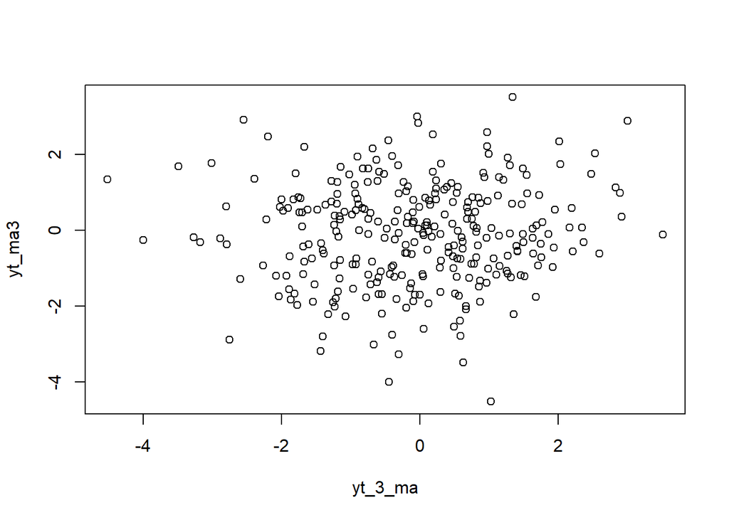

```r
plot(y=yt_ma3,x=yt_3_ma)
```

Berdasarkan scatterplot tersebut, terlihat bahwa cenderung tidak terdapat hubungan antara $Y_t$ dengan $Y_{t-3}$.

```r
cor(yt_ma3,yt_3_ma)
```

```
## [1] 0.05460628
```

### 2. Proses AR(2)

Bangkitkan model AR(2) dengan 𝜙1 = 0.5 dan 𝜙2 = 0.2 sebanyak 300 data (Manual dan dengan arima.sim)

## Proses AR

Proses AR dapat dituliskan sebagai berikut:

$$y_{t} = c + e_t + \phi_{1}Y_{t-1} +
\phi_{2}Y_{t-2} + \dots + \phi_{q}Y_{t-q} = c+{e_t+\sum_{i=1}^p
\phi_iY_{t-i}}$$
Terlihat bahwa $Y_t$ berperan penting dalam pembangkitan proses AR.

## Pembangkitan Proses AR

```r
set.seed(063)
```

Nilai-nilai selanjutnya dapat dicari melalui *loop*. Bentuk loop dapat dilihat dari rumus AR(2) yang hendak dibangkitkan:

$$Y_t = e_t+0.5.Y_{t-1}+0.2.Y_{t-2}$$

```r
n<-length(wn)
n
```

```
## [1] 300
```

```r
ar <- c(1:n)
for (i in 3:n) {ar[i]<-wn[i]+0.5*ar[i-1]}+0.2*ar[i-2]
ar
```

```
##   [1]  1.00000000  2.00000000 -1.66527819 -0.93100225 -3.34312767 -0.97868017
##   [7] -1.23675692  0.60653033  1.75145991  2.04225274  3.20181765  1.66983791
##  [13]  0.99219807  0.27926249 -0.47453987  0.04845966 -0.34989849  1.10922561
##  [19]  1.06922459  1.41717176  1.76061480  0.42395226 -0.33493642 -0.60311930
##  [25] -0.19289524  0.59281338  0.93713252  1.75648464  0.15587688  0.37382651
##  [31]  1.05364828 -0.17094889 -0.21166600  0.35447808  0.43051102 -0.67095593
##  [37]  0.48623042  0.86409514 -0.49900407 -0.72806337 -0.05638277 -1.89944708
##  [43] -0.34064946 -3.29116623 -2.50469659 -0.19381718 -0.25783517 -0.22012135
##  [49] -1.25154377 -1.30322710 -0.37772498  0.87425159  1.12160057  1.81366638
##  [55]  0.87514275  1.62356194  0.43684760  0.37477068 -0.61061751  0.04910083
##  [61] -0.88752692 -1.83338460 -1.74142556 -1.60863898 -1.90281025 -1.26100242
##  [67]  0.73663700 -1.54863154  0.14153892 -1.53117462 -1.41395235 -0.87360966
##  [73]  1.37789339 -0.02708431 -1.43100066 -1.93685831 -1.49224170 -1.16946659
##  [79]  0.19601173 -1.78571360  0.06366876 -0.84406862  0.17756344 -1.62547188
##  [85]  0.06260860  0.76690680  0.37985135  0.89570523  0.04182805 -0.95280334
```

[output cut: 35 more lines]

Selain menggunakan cara di atas, pembangkitan proses AR dapat dilakukan dengan fungsi `arima.sim()` sebagai berikut.

```r
ar1 <- arima.sim(list(order=c(2,0,0), ar=c(0.5, 0.2)), n=300)
ar1
```

```
## Time Series:
## Start = 1
## End = 300
## Frequency = 1
##   [1]  1.7836019643  1.5820894643 -0.1935411876  0.7041572088  0.4416460959
##   [6] -1.0137924012 -0.0003289047  0.3657357814  0.0574114577  1.0912966427
##  [11]  1.2209232147 -0.7036448500  1.4604143920  1.5701293924  1.9350808027
##  [16]  0.9634767019  0.8692408013  0.5775962138 -0.5164120492 -3.1674590314
##  [21] -0.1838375827 -0.2570652251  1.0500657532  0.7208958470  0.3770540284
##  [26]  0.8857161639  0.6244394265  0.5758157315 -0.8268399433 -0.5960842329
##  [31] -2.9502792969 -2.0666166536 -2.4082615229 -2.5444243580 -0.2386825557
##  [36] -1.2360345963 -0.0340597269 -1.1229525932 -0.2655047450 -1.0888467744
##  [41] -0.5630037144  0.0900786015  0.9134116452 -0.4036044120  0.0993335524
##  [46]  1.1804126892  0.5200555170  0.1865736848 -1.1488624541 -0.2978305536
##  [51] -0.5839418845 -1.6542408252 -1.7899569948 -0.2827445180 -0.4631189075
```

[output cut: 49 more lines]

## Karakteristik AR(1)

### Plot Time Series

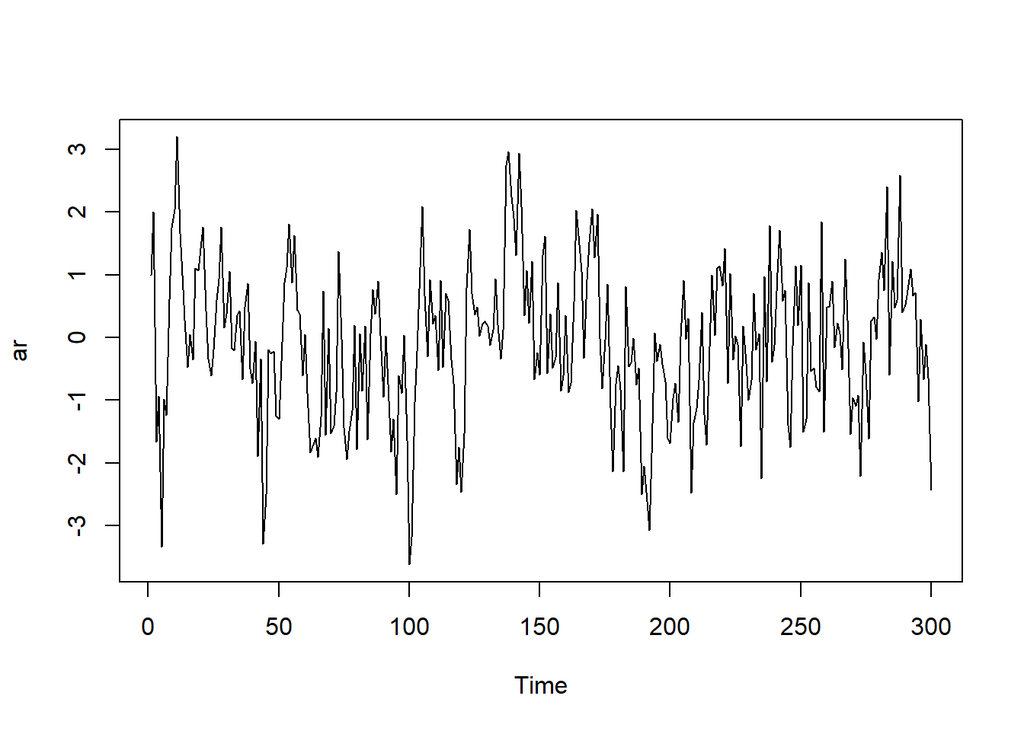

```r
ts.plot(ar)
```

Berdasarkan plot time series tersebut terlihat bahwa data cenderung stasioner pada rataan

### Plot ACF

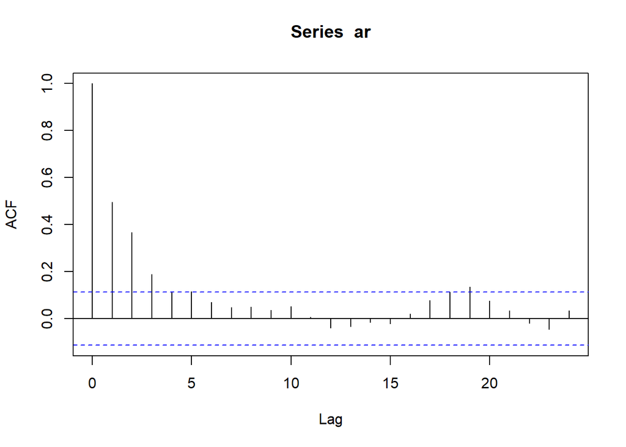

```r
acf(ar)
```

Berdasarkan plot ACF tersebut terlihat bahwa plot ACF cenderung *tails off*

### Plot PACF

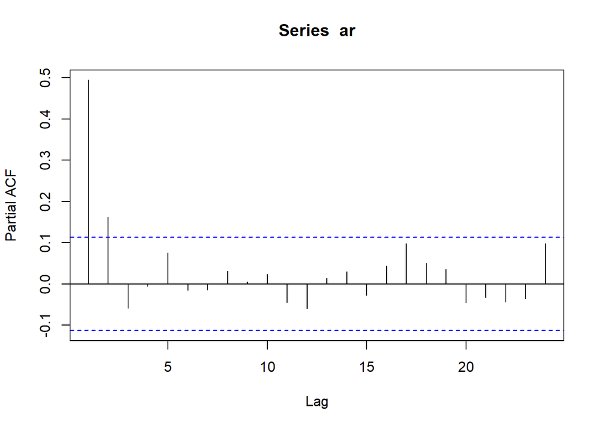

```r
pacf(ar)
```

### Plot EACF

```r
TSA::eacf(ar)
```

```
## AR/MA
##   0 1 2 3 4 5 6 7 8 9 10 11 12 13
## 0 x x x o o o o o o o o  o  o  o
## 1 x x o o o o o o o o o  o  o  o
## 2 x o o o o o o o o o o  o  o  o
## 3 o x x o o o o o o o o  o  o  o
## 4 o x x o o o o o o o o  o  o  o
## 5 x x x o o o o o o o o  o  o  o
## 6 x x x o o o o o o o o  o  o  o
## 7 x x x x o o o o o o o  o  o  o
```

Berdasarkan pola segitiga nol pada plot EACF, terlihat bahwa segitiga nol berada pada ordo AR(1) dan ordo MA(2).

Sehingga dapat disimpulkan bahwa data tersebut stasioner

### Scatterplot Antar Lag

#### Korelasi antara $Y_t$ dengan $Y_{t-1}$

```r
#Yt
yt_ar <- ar[-1]
yt_ar
```

```
##   [1]  2.00000000 -1.66527819 -0.93100225 -3.34312767 -0.97868017 -1.23675692
##   [7]  0.60653033  1.75145991  2.04225274  3.20181765  1.66983791  0.99219807
##  [13]  0.27926249 -0.47453987  0.04845966 -0.34989849  1.10922561  1.06922459
##  [19]  1.41717176  1.76061480  0.42395226 -0.33493642 -0.60311930 -0.19289524
##  [25]  0.59281338  0.93713252  1.75648464  0.15587688  0.37382651  1.05364828
##  [31] -0.17094889 -0.21166600  0.35447808  0.43051102 -0.67095593  0.48623042
##  [37]  0.86409514 -0.49900407 -0.72806337 -0.05638277 -1.89944708 -0.34064946
##  [43] -3.29116623 -2.50469659 -0.19381718 -0.25783517 -0.22012135 -1.25154377
##  [49] -1.30322710 -0.37772498  0.87425159  1.12160057  1.81366638  0.87514275
##  [55]  1.62356194  0.43684760  0.37477068 -0.61061751  0.04910083 -0.88752692
##  [61] -1.83338460 -1.74142556 -1.60863898 -1.90281025 -1.26100242  0.73663700
##  [67] -1.54863154  0.14153892 -1.53117462 -1.41395235 -0.87360966  1.37789339
##  [73] -0.02708431 -1.43100066 -1.93685831 -1.49224170 -1.16946659  0.19601173
##  [79] -1.78571360  0.06366876 -0.84406862  0.17756344 -1.62547188  0.06260860
##  [85]  0.76690680  0.37985135  0.89570523  0.04182805 -0.95280334  0.01982077
```

[output cut: 35 more lines]

```r
#Yt-1
yt_1_ar <- ar[-300]
yt_1_ar
```

```
##   [1]  1.00000000  2.00000000 -1.66527819 -0.93100225 -3.34312767 -0.97868017
##   [7] -1.23675692  0.60653033  1.75145991  2.04225274  3.20181765  1.66983791
##  [13]  0.99219807  0.27926249 -0.47453987  0.04845966 -0.34989849  1.10922561
##  [19]  1.06922459  1.41717176  1.76061480  0.42395226 -0.33493642 -0.60311930
##  [25] -0.19289524  0.59281338  0.93713252  1.75648464  0.15587688  0.37382651
##  [31]  1.05364828 -0.17094889 -0.21166600  0.35447808  0.43051102 -0.67095593
##  [37]  0.48623042  0.86409514 -0.49900407 -0.72806337 -0.05638277 -1.89944708
##  [43] -0.34064946 -3.29116623 -2.50469659 -0.19381718 -0.25783517 -0.22012135
##  [49] -1.25154377 -1.30322710 -0.37772498  0.87425159  1.12160057  1.81366638
##  [55]  0.87514275  1.62356194  0.43684760  0.37477068 -0.61061751  0.04910083
##  [61] -0.88752692 -1.83338460 -1.74142556 -1.60863898 -1.90281025 -1.26100242
##  [67]  0.73663700 -1.54863154  0.14153892 -1.53117462 -1.41395235 -0.87360966
##  [73]  1.37789339 -0.02708431 -1.43100066 -1.93685831 -1.49224170 -1.16946659
##  [79]  0.19601173 -1.78571360  0.06366876 -0.84406862  0.17756344 -1.62547188
##  [85]  0.06260860  0.76690680  0.37985135  0.89570523  0.04182805 -0.95280334
```

[output cut: 35 more lines]

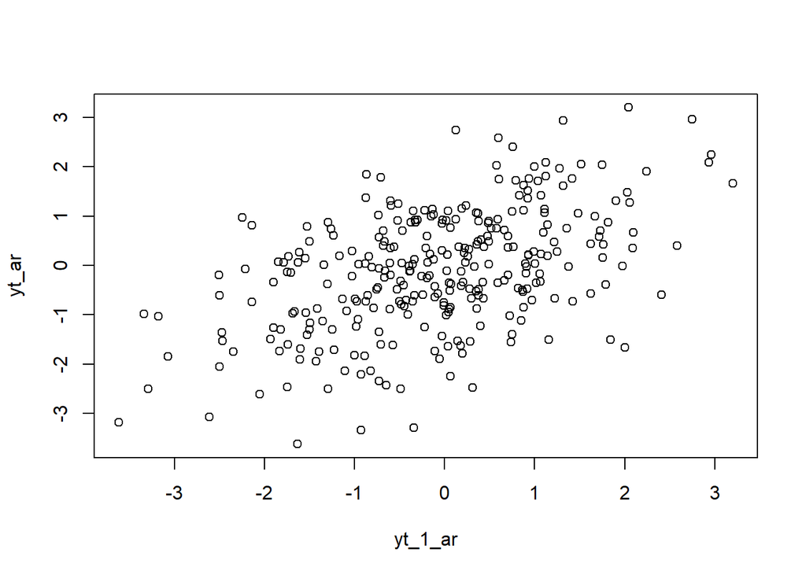

```r
plot(y=yt_ar,x=yt_1_ar)
```

Berdasarkan scatterplot tersebut, terlihat bahwa terdapat hubungan positif antara $Y_t$ dengan $Y_{t-1}$. Hal ini sesuai dengan teori yang ada

```r
cor(yt_ar,yt_1_ar)
```

```
## [1] 0.4983242
```

Korelasi antara $Y_t$ dengan $Y_{t-1}$ dari hasil simulasi mendekati perhitungan teoritis yaitu $\rho_1=\phi^1=0.5$

#### Korelasi antara $Y_t$ dengan $Y_{t-2}$

```r
#Yt
yt_ar2 <- ar[-c(1,2)]
yt_ar2
```

```
##   [1] -1.66527819 -0.93100225 -3.34312767 -0.97868017 -1.23675692  0.60653033
##   [7]  1.75145991  2.04225274  3.20181765  1.66983791  0.99219807  0.27926249
##  [13] -0.47453987  0.04845966 -0.34989849  1.10922561  1.06922459  1.41717176
##  [19]  1.76061480  0.42395226 -0.33493642 -0.60311930 -0.19289524  0.59281338
##  [25]  0.93713252  1.75648464  0.15587688  0.37382651  1.05364828 -0.17094889
##  [31] -0.21166600  0.35447808  0.43051102 -0.67095593  0.48623042  0.86409514
##  [37] -0.49900407 -0.72806337 -0.05638277 -1.89944708 -0.34064946 -3.29116623
##  [43] -2.50469659 -0.19381718 -0.25783517 -0.22012135 -1.25154377 -1.30322710
##  [49] -0.37772498  0.87425159  1.12160057  1.81366638  0.87514275  1.62356194
##  [55]  0.43684760  0.37477068 -0.61061751  0.04910083 -0.88752692 -1.83338460
##  [61] -1.74142556 -1.60863898 -1.90281025 -1.26100242  0.73663700 -1.54863154
##  [67]  0.14153892 -1.53117462 -1.41395235 -0.87360966  1.37789339 -0.02708431
##  [73] -1.43100066 -1.93685831 -1.49224170 -1.16946659  0.19601173 -1.78571360
##  [79]  0.06366876 -0.84406862  0.17756344 -1.62547188  0.06260860  0.76690680
##  [85]  0.37985135  0.89570523  0.04182805 -0.95280334  0.01982077 -1.00277205
```

[output cut: 35 more lines]

```r
#Yt-2
yt_2_ar <- ar[-c(299,300)]
yt_2_ar
```

```
##   [1]  1.00000000  2.00000000 -1.66527819 -0.93100225 -3.34312767 -0.97868017
##   [7] -1.23675692  0.60653033  1.75145991  2.04225274  3.20181765  1.66983791
##  [13]  0.99219807  0.27926249 -0.47453987  0.04845966 -0.34989849  1.10922561
##  [19]  1.06922459  1.41717176  1.76061480  0.42395226 -0.33493642 -0.60311930
##  [25] -0.19289524  0.59281338  0.93713252  1.75648464  0.15587688  0.37382651
##  [31]  1.05364828 -0.17094889 -0.21166600  0.35447808  0.43051102 -0.67095593
##  [37]  0.48623042  0.86409514 -0.49900407 -0.72806337 -0.05638277 -1.89944708
##  [43] -0.34064946 -3.29116623 -2.50469659 -0.19381718 -0.25783517 -0.22012135
##  [49] -1.25154377 -1.30322710 -0.37772498  0.87425159  1.12160057  1.81366638
##  [55]  0.87514275  1.62356194  0.43684760  0.37477068 -0.61061751  0.04910083
##  [61] -0.88752692 -1.83338460 -1.74142556 -1.60863898 -1.90281025 -1.26100242
##  [67]  0.73663700 -1.54863154  0.14153892 -1.53117462 -1.41395235 -0.87360966
##  [73]  1.37789339 -0.02708431 -1.43100066 -1.93685831 -1.49224170 -1.16946659
##  [79]  0.19601173 -1.78571360  0.06366876 -0.84406862  0.17756344 -1.62547188
##  [85]  0.06260860  0.76690680  0.37985135  0.89570523  0.04182805 -0.95280334
```

[output cut: 35 more lines]

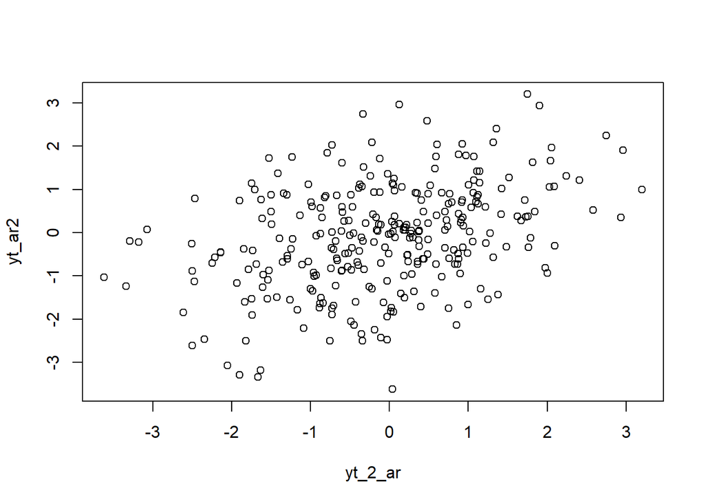

```r
plot(y=yt_ar2,x=yt_2_ar)
```

Berdasarkan scatterplot tersebut, terlihat bahwa terdapat hubungan positif yang lemah antara $Y_t$ dengan $Y_{t-2}$. Hal ini sesuai dengan teori yang ada

```r
cor(yt_ar2,yt_2_ar)
```

```
## [1] 0.3719358
```

#### Korelasi antara $Y_t$ dengan $Y_{t-3}$

```r
#Yt
yt_ar3 <- ar[-c(1,2,3)]
yt_ar3
```

```
##   [1] -0.93100225 -3.34312767 -0.97868017 -1.23675692  0.60653033  1.75145991
##   [7]  2.04225274  3.20181765  1.66983791  0.99219807  0.27926249 -0.47453987
##  [13]  0.04845966 -0.34989849  1.10922561  1.06922459  1.41717176  1.76061480
##  [19]  0.42395226 -0.33493642 -0.60311930 -0.19289524  0.59281338  0.93713252
##  [25]  1.75648464  0.15587688  0.37382651  1.05364828 -0.17094889 -0.21166600
##  [31]  0.35447808  0.43051102 -0.67095593  0.48623042  0.86409514 -0.49900407
##  [37] -0.72806337 -0.05638277 -1.89944708 -0.34064946 -3.29116623 -2.50469659
##  [43] -0.19381718 -0.25783517 -0.22012135 -1.25154377 -1.30322710 -0.37772498
##  [49]  0.87425159  1.12160057  1.81366638  0.87514275  1.62356194  0.43684760
##  [55]  0.37477068 -0.61061751  0.04910083 -0.88752692 -1.83338460 -1.74142556
##  [61] -1.60863898 -1.90281025 -1.26100242  0.73663700 -1.54863154  0.14153892
##  [67] -1.53117462 -1.41395235 -0.87360966  1.37789339 -0.02708431 -1.43100066
##  [73] -1.93685831 -1.49224170 -1.16946659  0.19601173 -1.78571360  0.06366876
##  [79] -0.84406862  0.17756344 -1.62547188  0.06260860  0.76690680  0.37985135
##  [85]  0.89570523  0.04182805 -0.95280334  0.01982077 -1.00277205 -1.82206177
```

[output cut: 35 more lines]

```r
#Yt-2
yt_3_ar <- ar[-c(298,299,300)]
yt_3_ar
```

```
##   [1]  1.00000000  2.00000000 -1.66527819 -0.93100225 -3.34312767 -0.97868017
##   [7] -1.23675692  0.60653033  1.75145991  2.04225274  3.20181765  1.66983791
##  [13]  0.99219807  0.27926249 -0.47453987  0.04845966 -0.34989849  1.10922561
##  [19]  1.06922459  1.41717176  1.76061480  0.42395226 -0.33493642 -0.60311930
##  [25] -0.19289524  0.59281338  0.93713252  1.75648464  0.15587688  0.37382651
##  [31]  1.05364828 -0.17094889 -0.21166600  0.35447808  0.43051102 -0.67095593
##  [37]  0.48623042  0.86409514 -0.49900407 -0.72806337 -0.05638277 -1.89944708
##  [43] -0.34064946 -3.29116623 -2.50469659 -0.19381718 -0.25783517 -0.22012135
##  [49] -1.25154377 -1.30322710 -0.37772498  0.87425159  1.12160057  1.81366638
##  [55]  0.87514275  1.62356194  0.43684760  0.37477068 -0.61061751  0.04910083
##  [61] -0.88752692 -1.83338460 -1.74142556 -1.60863898 -1.90281025 -1.26100242
##  [67]  0.73663700 -1.54863154  0.14153892 -1.53117462 -1.41395235 -0.87360966
##  [73]  1.37789339 -0.02708431 -1.43100066 -1.93685831 -1.49224170 -1.16946659
##  [79]  0.19601173 -1.78571360  0.06366876 -0.84406862  0.17756344 -1.62547188
##  [85]  0.06260860  0.76690680  0.37985135  0.89570523  0.04182805 -0.95280334
```

[output cut: 35 more lines]

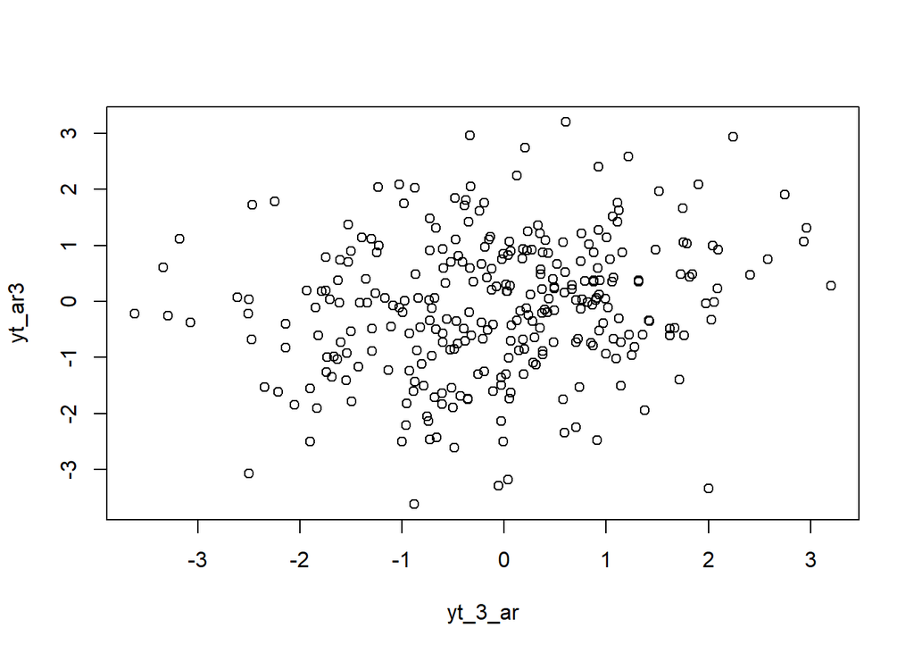

```r
plot(y=yt_ar3,x=yt_3_ar)
```

Berdasarkan scatterplot tersebut, terlihat bahwa cenderung terdapat hubungan positif yang sangat lemah antara $Y_t$ dengan $Y_{t-3}$. Hal ini sesuai dengan teori yang ada

```r
cor(yt_ar3,yt_3_ar)
```

```
## [1] 0.1920923
```

### 3. ARMA (2,2)

Bangkitkan model AR(2) dengan 𝜃1 = 0.4, 𝜃2 = 0.6 ,𝜙1 = 0.5 dan𝜙2 = 0.2 sebanyak 300 data (Manual dan arima.sim)

## Fungsi pembangkitan ARMA

```r
set.seed(063)
n = length(wn)
phi1 = 0.5
phi2 = 0.2
theta1 = 0.4
theta2 = 0.6

y.arma=c(1:n)
for (i in 3:n){y.arma[i] = phi1*y.arma[i-1] + phi2*y.arma[i-2]+ theta1*wn[i-1]+theta2*wn[i-2]+wn[i]};head(y.arma)
```

```
## [1]  1.0000000  2.0000000 -0.2013133 -0.2457789 -4.6792908 -2.9059860
```

Pembangkitan ARMA(p,q) juga dapat dilakukan dengan fungsi `arima.sim` sebagai berikut.

```r
arma22 <- arima.sim(list(order=c(2,0,2), ar = c(0.5,0.2), ma =c(0.4,0.6)), n=300)
head(arma22)
```

```
## [1]  1.5096703  1.5761579  0.6073089 -0.4145446 -0.1407858 -0.2426160
```

#### Buat plot time series, plot ACF, plot PACF dan plot EACF. Idenifikasi apakah data tersebut stasioner

## Plot Time Series

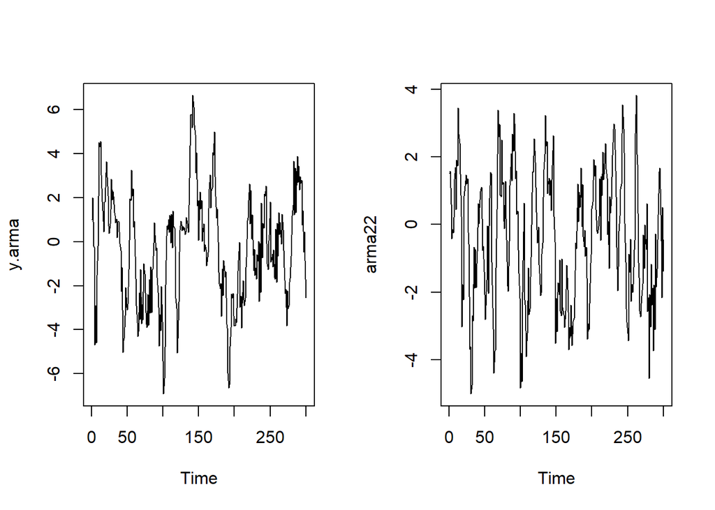

```r
par(mfrow = c(1, 2))
ts.plot(y.arma)
ts.plot(arma22)
```

```r
par(mfrow = c(1, 1))
```

Berdasarkan plot time series tersebut, terlihat bahwa model ARMA(2,2) cenderung stasioner dalam rataan

## Plot ACF

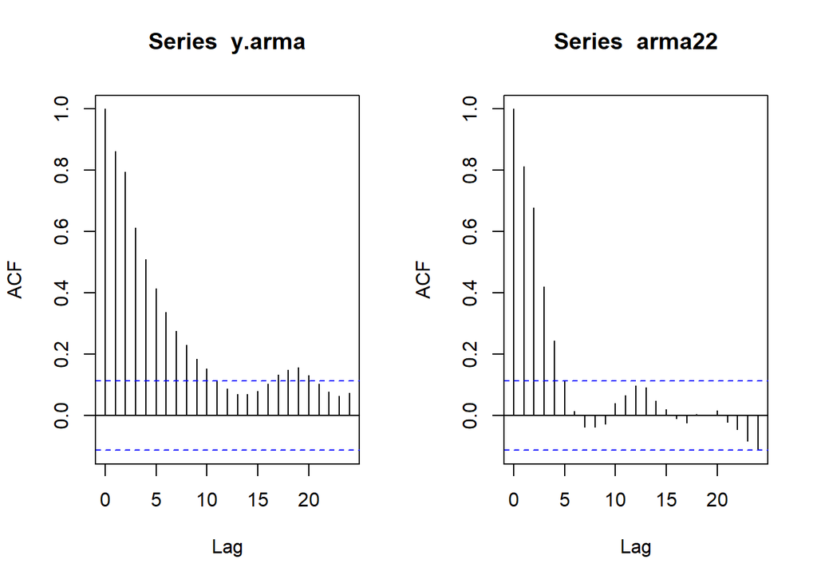

```r
par(mfrow = c(1, 2))
acf(y.arma)
acf(arma22)
```

```r
par(mfrow = c(1, 1))
```

Berdasarkan plot ACF tersebut, terlihat bahwa model ARMA(2,2) hasil simulasi memiliki plot ACF yang *tails off*, sesuai dengan teori yang ada

## Plot PACF

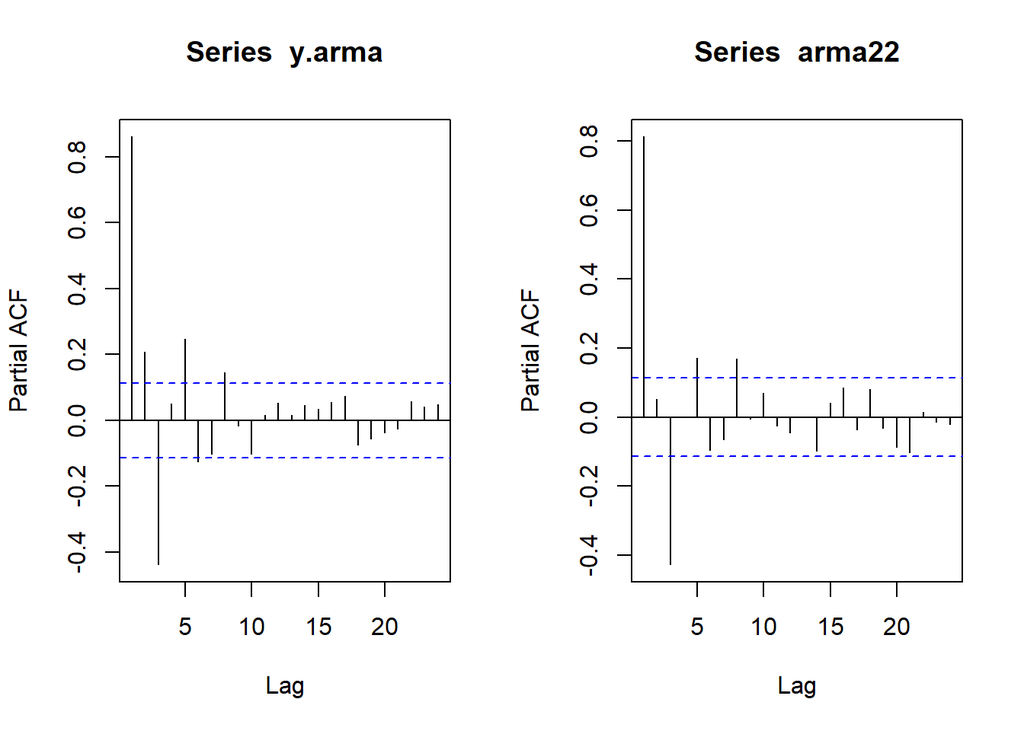

```r
par(mfrow = c(1, 2))
pacf(y.arma)
pacf(arma22)
```

```r
par(mfrow = c(1, 1))
```

## Plot EACF

```r
TSA::eacf(y.arma)
```

```
## AR/MA
##   0 1 2 3 4 5 6 7 8 9 10 11 12 13
## 0 x x x x x x x x x x o  o  o  o
## 1 x x x o o o o o o o o  o  o  o
## 2 x x o o o o o o o o o  o  o  o
## 3 x x x o o o o o o o o  o  o  o
## 4 x x x x o o o o o o o  o  o  o
## 5 x x o o x o o o o o o  o  o  o
## 6 x x o x o o o o o o o  o  o  o
## 7 x x x x x o o o o o o  o  o  o
```

```r
TSA::eacf(arma22)
```

```
## AR/MA
##   0 1 2 3 4 5 6 7 8 9 10 11 12 13
## 0 x x x x o o o o o o o  o  o  o
## 1 o x o o o o x o o o o  o  o  o
## 2 x x x o o o o o o o o  o  o  o
## 3 o x x x o o o o o x o  o  o  o
## 4 o x x x o o o o o o o  o  o  o
## 5 x x o x o o o o o o o  o  o  o
## 6 x x x o x x o o o o o  o  o  o
## 7 x x x o x x x o o o o  o  o  o
```

## Korelasi antara $Y_t$ dengan $Y_{t-1}$

```r
#Yt
yt_arma <- arma22[-1]
#Yt-1
yt_1_arma <- arma22[-300]
```

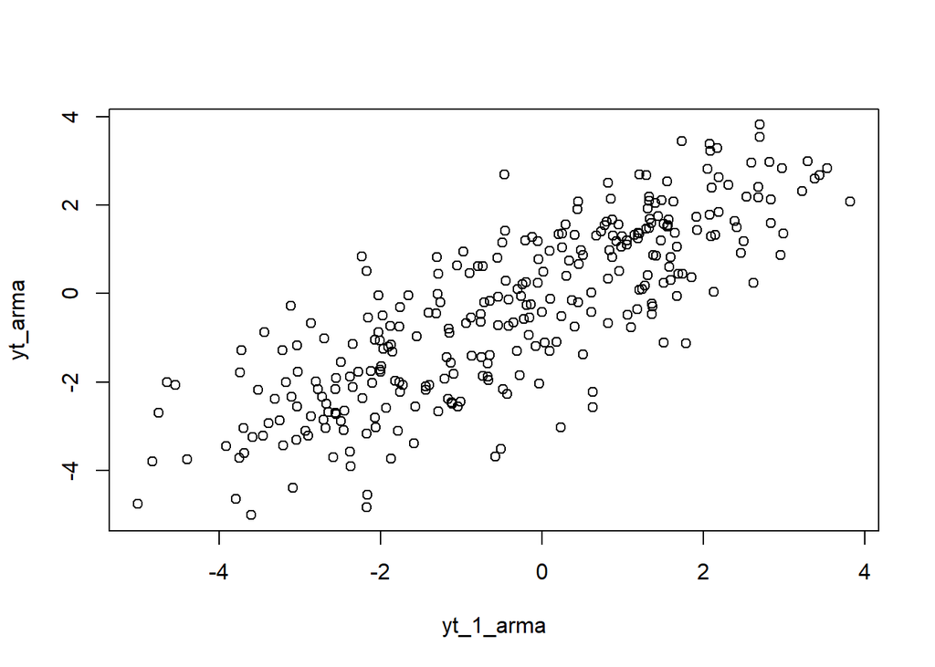

```r
plot(y=yt_arma,x=yt_1_arma)
```

Berdasarkan scatterplot tersebut, terlihat bahwa terdapat hubungan positif antara $Y_t$ dengan $Y_{t-1}$. Hal ini sesuai dengan teori yang ada

```r
cor(yt_arma,yt_1_arma)
```

```
## [1] 0.814294
```

## Korelasi antara $Y_t$ dengan $Y_{t-2}$

```r
#Yt
yt_arma2 <- arma22[-c(1,2)]
#Yt-2
yt_2_arma <- arma22[-c(299,300)]
```

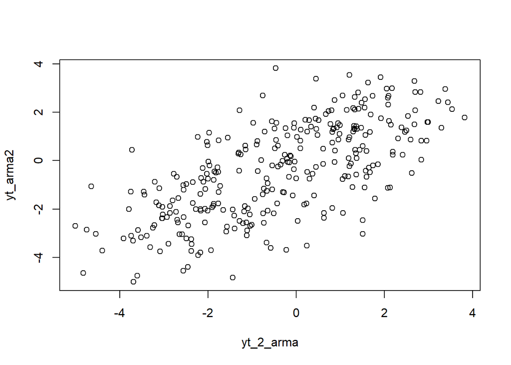

```r
plot(y=yt_arma2,x=yt_2_arma)
```

Berdasarkan scatterplot tersebut, terlihat bahwa terdapat hubungan positif antara $Y_t$ dengan $Y_{t-2}$. Hal ini sesuai dengan teori yang ada

```r
cor(yt_arma2,yt_2_arma)
```

```
## [1] 0.6810467
```

## Korelasi antara $Y_t$ dengan $Y_{t-3}$

```r
#Yt
yt_arma3 <- arma22[-c(1,2,3)]
#Yt-3
yt_3_arma <- arma22[-c(298,299,300)]
```

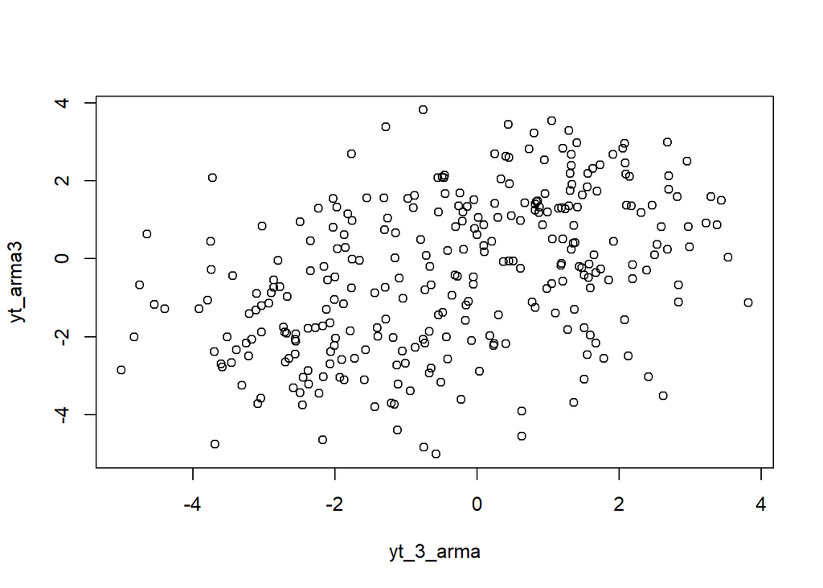

```r
plot(y=yt_arma3,x=yt_3_arma)
```

Berdasarkan scatterplot tersebut, terlihat bahwa terdapat hubungan positif antara $Y_t$ dengan $Y_{t-3}$. Hal ini sesuai dengan teori yang ada

```r
cor(yt_arma3,yt_3_arma)
```

```
## [1] 0.4227412
```